# Results Preview

Published

June 12, 2026

**Note**

Unless specified otherwise, temperature refers to the 7 day mean of temperature

# Main Effects

## Temperature Effects

Here, we estimate the impact of temperature on mental health directly, without the influence of shocks.

In particular, we estimate

$$Y_{ict} =
+ \beta_1 Temp_{ict}
+ X_{ict}'\Gamma
+ \alpha_c + \lambda_m + \delta_y + \pi_w
+ \varepsilon_{ict},$$

where $Y_{ict}$ is respondent $i$’s CES-D z-score (or sleep hours) in community $c$ at interview date $t$, $Temp_{ict}$ is the temperature measure shown in the tab, and the remaining terms are demographic and fixed effects described in the main effects section

**CES-D**

[output not shown]

Significance levels: * p < 0.1, ** p < 0.05, *** p < 0.01. Format of coefficient cell: Coefficient (Std. Error)

**Non-linear Effects of Temperature**

Following Fritz, 2026 I estimate the non-linear impacts of temperature on mental health. The effect of wetbulb is very linear with hotter days being better for mental health. For regular temperature, there is no clear pattern (most coeffs are close to null) with one coeff, days between 21-22.5 being an improvment over our reference temperature

**Past 30-Day Mean Temperature Bins**

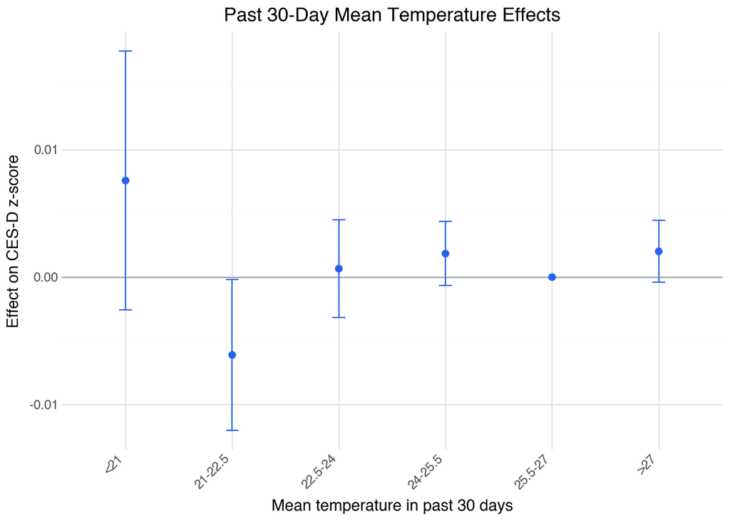

**Past 30-Day Wet-Bulb Temperature Bins**

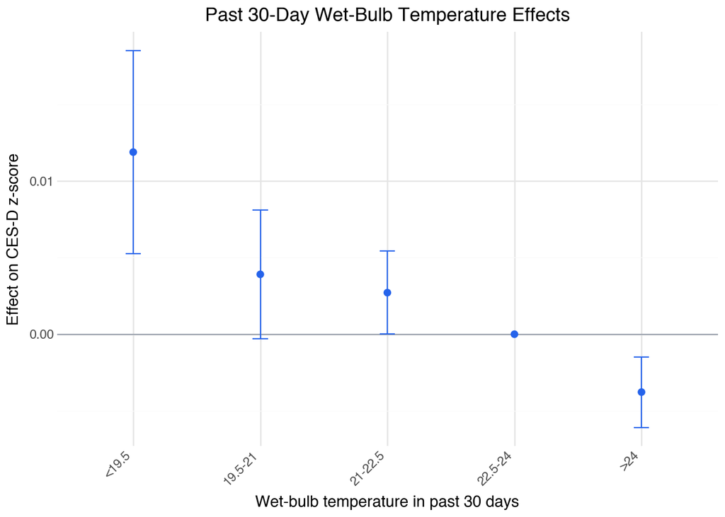

**Sleep Hours**

[output not shown]

Significance levels: * p < 0.1, ** p < 0.05, *** p < 0.01. Format of coefficient cell: Coefficient (Std. Error)

## Main Table

The main shock tables estimate heat amplification among baseline stressor groups. Let $Y_{ict}$ be respondent $i$’s CES-D z-score in community $c$ at interview date $t$, $H_{ict}$ be the temperature measure shown in the tab, $X_{ict}$ be age, female, years of education, married, and widowed controls, and $\alpha_c$, $\lambda_m$, $\delta_y$, and $\pi_w$ be community, month, year, and wave fixed effects. Standard errors are clustered by kecamatan in the paper tables.

For the baseline job-loss shock:

$$Y_{ict} =
\beta_1 H_{ict}
+ \beta_2 J_{ict}
+ \beta_3 (H_{ict} \times J_{ict})
+ X_{ict}'\Gamma
+ \alpha_c + \lambda_m + \delta_y + \pi_w
+ \varepsilon_{ict},$$

where $J_{ict}$ indicates job loss within the past year while currently not working. The reported shock coefficient is $\beta_3$.

For baseline-group shocks observed before the later exposure period:

$$Y_{ict} =
\beta_1 H_{ict}
+ \beta_2 G_i
+ \beta_3 P_t
+ \beta_4 (G_i \times P_t)
+ \beta_5 (H_{ict} \times G_i)
+ \beta_6 (H_{ict} \times P_t)
+ \beta_7 (H_{ict} \times G_i \times P_t)
+ X_{ict}'\Gamma
+ \alpha_c + \lambda_m + \delta_y
+ \varepsilon_{ict}.$$

Here $G_i$ is the baseline group indicator and $P_t$ is the post indicator. The palm and coal columns use $P_t=\mathbf{1}\{\text{IFLS5}\}$; the fuel column is estimated within IFLS5 and uses $P_t=\mathbf{1}\{\text{interview date} \ge \text{2014-11-18}\}$. The reported shock coefficient is $\beta_7$.

**Daily Mean**

|  | CES-D z-score Palm Shock (1) | CES-D z-score Fuel Cut (2) | CES-D z-score Coal Shock (3) | CES-D z-score Job Loss (4) |
| --- | --- | --- | --- | --- |
| coef |  |  |  |  |
| Group × Post × Heat | 0.068*** (0.012) | 0.037 (0.024) | 0.075 (0.168) |  |
| Group × Heat | -0.027** (0.013) | -0.032 (0.020) | -0.044 (0.146) | 0.056** (0.025) |
| Heat | 0.011 (0.008) | 0.036** (0.018) | 0.004 (0.008) | 0.011 (0.007) |
| Group × Post | -0.114*** (0.029) | -0.032 (0.047) | -0.048 (0.159) |  |
| Group | 0.065** (0.029) | -0.030 (0.042) | -0.019 (0.108) | 0.113*** (0.043) |
| Post × Heat | -0.005 (0.006) | -0.005 (0.019) | 0.011** (0.005) |  |
| Post |  | -0.067 (0.056) |  |  |
| fe |  |  |  |  |
| Kecamatan fixed effects | x | x | x | x |
| Wave: IFLS5 | - | - | - | x |
| Month | x | x | x | x |
| Year | x | x | x | x |
| stats |  |  |  |  |
| Heat effect on treated | 0.051*** | 0.041* | 0.035 |  |
| S.E. | 0.014 | 0.022 | 0.086 |  |
| Observations | 50,005 | 21,066 | 50,005 | 50,005 |
| R<sup>2</sup> | 0.085 | 0.128 | 0.084 | 0.084 |

Significance levels: * p < 0.1, ** p < 0.05, *** p < 0.01. Format of coefficient cell: Coefficient (Std. Error)

**7-day mean**

|  | CES-D z-score Palm Shock (1) | CES-D z-score Fuel Cut (2) | CES-D z-score Coal Shock (3) | CES-D z-score Job Loss (4) |
| --- | --- | --- | --- | --- |
| coef |  |  |  |  |
| Group × Post × Heat | 0.073*** (0.013) | 0.050** (0.025) | 0.152 (0.177) |  |
| Group × Heat | -0.031** (0.014) | -0.036* (0.021) | -0.027 (0.149) | 0.042 (0.026) |
| Heat | 0.005 (0.010) | 0.033 (0.023) | -0.003 (0.010) | 0.006 (0.009) |
| Group × Post | -0.114*** (0.029) | -0.039 (0.048) | -0.107 (0.161) |  |
| Group | 0.063** (0.030) | -0.025 (0.043) | -0.026 (0.109) | 0.112*** (0.043) |
| Post × Heat | -0.005 (0.006) | -0.012 (0.022) | 0.013** (0.005) |  |
| Post |  | -0.055 (0.057) |  |  |
| fe |  |  |  |  |
| Kecamatan fixed effects | x | x | x | x |
| Wave: IFLS5 | - | - | - | x |
| Month | x | x | x | x |
| Year | x | x | x | x |
| stats |  |  |  |  |
| Heat effect on treated | 0.047*** | 0.047* | 0.123 |  |
| S.E. | 0.016 | 0.026 | 0.101 |  |
| Observations | 50,005 | 21,066 | 50,005 | 50,005 |
| R<sup>2</sup> | 0.085 | 0.128 | 0.084 | 0.084 |

Significance levels: * p < 0.1, ** p < 0.05, *** p < 0.01. Format of coefficient cell: Coefficient (Std. Error)

**Wet-bulb current**

|  | CES-D z-score Palm Shock (1) | CES-D z-score Fuel Cut (2) | CES-D z-score Coal Shock (3) | CES-D z-score Job Loss (4) |
| --- | --- | --- | --- | --- |
| coef |  |  |  |  |
| Group × Post × Heat | 0.079*** (0.015) | 0.081*** (0.028) | -0.036 (0.240) |  |
| Group × Heat | -0.035** (0.015) | -0.053** (0.023) | 0.030 (0.171) | 0.041 (0.031) |
| Heat | 0.010 (0.011) | 0.062*** (0.021) | 0.000 (0.011) | 0.013 (0.010) |
| Group × Post | -0.123*** (0.028) | -0.000 (0.042) | 0.007 (0.224) |  |
| Group | 0.071** (0.028) | -0.071** (0.036) | -0.051 (0.154) | 0.109** (0.043) |
| Post × Heat | 0.003 (0.007) | -0.011 (0.023) | 0.021*** (0.006) |  |
| Post |  | -0.102* (0.057) |  |  |
| fe |  |  |  |  |
| Kecamatan fixed effects | x | x | x | x |
| Wave: IFLS5 | - | - | - | x |
| Month | x | x | x | x |
| Year | x | x | x | x |
| stats |  |  |  |  |
| Heat effect on treated | 0.054*** | 0.090*** | -0.006 |  |
| S.E. | 0.019 | 0.026 | 0.171 |  |
| Observations | 50,005 | 21,066 | 50,005 | 50,005 |
| R<sup>2</sup> | 0.085 | 0.129 | 0.084 | 0.084 |

Significance levels: * p < 0.1, ** p < 0.05, *** p < 0.01. Format of coefficient cell: Coefficient (Std. Error)

**Wet-bulb 7-day**

|  | CES-D z-score Palm Shock (1) | CES-D z-score Fuel Cut (2) | CES-D z-score Coal Shock (3) | CES-D z-score Job Loss (4) |
| --- | --- | --- | --- | --- |
| coef |  |  |  |  |
| Group × Post × Heat | 0.079*** (0.015) | 0.089*** (0.030) | 0.056 (0.280) |  |
| Group × Heat | -0.042*** (0.015) | -0.056** (0.025) | 0.102 (0.163) | 0.042 (0.031) |
| Heat | -0.035*** (0.013) | 0.025 (0.030) | -0.045*** (0.013) | -0.032*** (0.012) |
| Group × Post | -0.123*** (0.028) | -0.001 (0.042) | -0.071 (0.252) |  |
| Group | 0.070** (0.028) | -0.074** (0.036) | -0.101 (0.151) | 0.109** (0.043) |
| Post × Heat | 0.003 (0.007) | 0.004 (0.028) | 0.023*** (0.006) |  |
| Post |  | -0.099* (0.057) |  |  |
| fe |  |  |  |  |
| Kecamatan fixed effects | x | x | x | x |
| Wave: IFLS5 | - | - | - | x |
| Month | x | x | x | x |
| Year | x | x | x | x |
| stats |  |  |  |  |
| Heat effect on treated | 0.002 | 0.057* | 0.112 |  |
| S.E. | 0.021 | 0.034 | 0.230 |  |
| Observations | 50,005 | 21,066 | 50,005 | 50,005 |
| R<sup>2</sup> | 0.085 | 0.128 | 0.084 | 0.084 |

Significance levels: * p < 0.1, ** p < 0.05, *** p < 0.01. Format of coefficient cell: Coefficient (Std. Error)

**7-day hot days**

|  | CES-D z-score Palm Shock (1) | CES-D z-score Fuel Cut (2) | CES-D z-score Coal Shock (3) | CES-D z-score Job Loss (4) |
| --- | --- | --- | --- | --- |
| coef |  |  |  |  |
| Group × Post × Heat | 0.052*** (0.014) | 0.005 (0.015) | 0.072 (0.069) |  |
| Group × Heat | -0.035*** (0.014) | -0.006 (0.012) | -0.006 (0.055) | 0.006 (0.018) |
| Heat | 0.012** (0.005) | 0.007 (0.012) | 0.009* (0.005) | -0.003 (0.003) |
| Group × Post | -0.129*** (0.029) | -0.011 (0.052) | -0.012 (0.141) |  |
| Group | 0.063** (0.030) | -0.051 (0.047) | -0.042 (0.099) | 0.115*** (0.043) |
| Post × Heat | -0.022*** (0.006) | -0.008 (0.013) | -0.017*** (0.005) |  |
| Post |  | -0.054 (0.058) |  |  |
| fe |  |  |  |  |
| Kecamatan fixed effects | x | x | x | x |
| Wave: IFLS5 | - | - | - | x |
| Month | x | x | x | x |
| Year | x | x | x | x |
| stats |  |  |  |  |
| Heat effect on treated | 0.028** | 0.007 | 0.074* |  |
| S.E. | 0.011 | 0.015 | 0.044 |  |
| Observations | 50,005 | 21,066 | 50,005 | 50,005 |
| R<sup>2</sup> | 0.085 | 0.128 | 0.084 | 0.084 |

Significance levels: * p < 0.1, ** p < 0.05, *** p < 0.01. Format of coefficient cell: Coefficient (Std. Error)

## Panel Style

The regressions below omit group effects and instead include individual fixed effects

**Daily Mean**

|  | CES-D z-score Palm Shocks - Panel (1) | CES-D z-score Fuel Cut - Panel (2) | CES-D z-score Coal Shock - Panel (3) |
| --- | --- | --- | --- |
| coef |  |  |  |
| Group × Post × Heat | 0.069*** (0.013) | -0.015 (0.013) | 0.240 (0.214) |
| Group × Heat | -0.039 (0.027) | -0.002 (0.015) | -0.122 (0.237) |
| Heat | 0.013 (0.010) | 0.010 (0.010) | 0.004 (0.009) |
| Group × Post | -0.121*** (0.030) | 0.005 (0.023) | -0.100 (0.165) |
| Post × Heat | -0.004 (0.006) | 0.022*** (0.007) | 0.013** (0.005) |
| fe |  |  |  |
| Kecamatan fixed effects | x | x | x |
| Wave: IFLS5 | x | - | x |
| Month | x | x | x |
| Individual | x | x | x |
| Post-subsidy-cut interview | - | x | - |
| Year | x | x | x |
| stats |  |  |  |
| Heat effect on treated | 0.044* | -0.007 | 0.122 |
| S.E. | 0.023 | 0.017 | 0.123 |
| Observations | 41,546 | 41,546 | 41,546 |
| R<sup>2</sup> | 0.636 | 0.635 | 0.635 |

Significance levels: * p < 0.1, ** p < 0.05, *** p < 0.01. Format of coefficient cell: Coefficient (Std. Error)

**7-day mean**

|  | CES-D z-score Palm Shocks - Panel (1) | CES-D z-score Fuel Cut - Panel (2) | CES-D z-score Coal Shock - Panel (3) |
| --- | --- | --- | --- |
| coef |  |  |  |
| Group × Post × Heat | 0.076*** (0.013) | -0.011 (0.014) | 0.434** (0.217) |
| Group × Heat | -0.071** (0.033) | 0.002 (0.017) | -0.242 (0.272) |
| Heat | 0.018 (0.012) | 0.015 (0.012) | 0.006 (0.011) |
| Group × Post | -0.107*** (0.032) | 0.003 (0.023) | -0.171 (0.163) |
| Post × Heat | -0.005 (0.006) | 0.023*** (0.007) | 0.013** (0.005) |
| fe |  |  |  |
| Kecamatan fixed effects | x | x | x |
| Wave: IFLS5 | x | - | x |
| Month | x | x | x |
| Individual | x | x | x |
| Post-subsidy-cut interview | - | x | - |
| Year | x | x | x |
| stats |  |  |  |
| Heat effect on treated | 0.023 | 0.006 | 0.198 |
| S.E. | 0.030 | 0.019 | 0.164 |
| Observations | 41,546 | 41,546 | 41,546 |
| R<sup>2</sup> | 0.636 | 0.635 | 0.635 |

Significance levels: * p < 0.1, ** p < 0.05, *** p < 0.01. Format of coefficient cell: Coefficient (Std. Error)

**Wet-bulb current**

|  | CES-D z-score Palm Shocks - Panel (1) | CES-D z-score Fuel Cut - Panel (2) | CES-D z-score Coal Shock - Panel (3) |
| --- | --- | --- | --- |
| coef |  |  |  |
| Group × Post × Heat | 0.074*** (0.015) | -0.006 (0.015) | 0.249 (0.299) |
| Group × Heat | -0.081** (0.038) | -0.007 (0.020) | -0.387 (0.270) |
| Heat | -0.007 (0.014) | -0.013 (0.014) | -0.021 (0.013) |
| Group × Post | -0.134*** (0.027) | 0.003 (0.024) | -0.157 (0.257) |
| Post × Heat | 0.004 (0.007) | 0.032*** (0.008) | 0.023*** (0.006) |
| fe |  |  |  |
| Kecamatan fixed effects | x | x | x |
| Wave: IFLS5 | x | - | x |
| Month | x | x | x |
| Individual | x | x | x |
| Post-subsidy-cut interview | - | x | - |
| Year | x | x | x |
| stats |  |  |  |
| Heat effect on treated | -0.014 | -0.025 | -0.159 |
| S.E. | 0.039 | 0.022 | 0.242 |
| Observations | 41,546 | 41,546 | 41,546 |
| R<sup>2</sup> | 0.636 | 0.635 | 0.635 |

Significance levels: * p < 0.1, ** p < 0.05, *** p < 0.01. Format of coefficient cell: Coefficient (Std. Error)

**Wet-bulb 7-day**

|  | CES-D z-score Palm Shocks - Panel (1) | CES-D z-score Fuel Cut - Panel (2) | CES-D z-score Coal Shock - Panel (3) |
| --- | --- | --- | --- |
| coef |  |  |  |
| Group × Post × Heat | 0.075*** (0.015) | -0.001 (0.016) | 0.335 (0.340) |
| Group × Heat | -0.164*** (0.044) | 0.009 (0.022) | -0.412 (0.266) |
| Heat | -0.036** (0.016) | -0.050*** (0.017) | -0.054*** (0.015) |
| Group × Post | -0.126*** (0.028) | -0.004 (0.024) | -0.209 (0.287) |
| Post × Heat | 0.004 (0.007) | 0.034*** (0.008) | 0.025*** (0.006) |
| fe |  |  |  |
| Kecamatan fixed effects | x | x | x |
| Wave: IFLS5 | x | - | x |
| Month | x | x | x |
| Individual | x | x | x |
| Post-subsidy-cut interview | - | x | - |
| Year | x | x | x |
| stats |  |  |  |
| Heat effect on treated | -0.125*** | -0.042* | -0.130 |
| S.E. | 0.046 | 0.024 | 0.346 |
| Observations | 41,546 | 41,546 | 41,546 |
| R<sup>2</sup> | 0.636 | 0.635 | 0.635 |

Significance levels: * p < 0.1, ** p < 0.05, *** p < 0.01. Format of coefficient cell: Coefficient (Std. Error)

**7-day hot days**

|  | CES-D z-score Palm Shocks - Panel (1) | CES-D z-score Fuel Cut - Panel (2) | CES-D z-score Coal Shock - Panel (3) |
| --- | --- | --- | --- |
| coef |  |  |  |
| Group × Post × Heat | 0.066*** (0.016) | -0.009 (0.012) | 0.133 (0.084) |
| Group × Heat | -0.057*** (0.018) | 0.005 (0.007) | 0.017 (0.094) |
| Heat | 0.019*** (0.007) | 0.007 (0.005) | 0.012* (0.006) |
| Group × Post | -0.123*** (0.030) | 0.009 (0.024) | 0.015 (0.150) |
| Post × Heat | -0.028*** (0.007) | -0.029*** (0.008) | -0.019*** (0.006) |
| fe |  |  |  |
| Kecamatan fixed effects | x | x | x |
| Wave: IFLS5 | x | - | x |
| Month | x | x | x |
| Individual | x | x | x |
| Post-subsidy-cut interview | - | x | - |
| Year | x | x | x |
| stats |  |  |  |
| Heat effect on treated | 0.028** | 0.002 | 0.162** |
| S.E. | 0.014 | 0.012 | 0.067 |
| Observations | 41,546 | 41,546 | 41,546 |
| R<sup>2</sup> | 0.636 | 0.635 | 0.635 |

Significance levels: * p < 0.1, ** p < 0.05, *** p < 0.01. Format of coefficient cell: Coefficient (Std. Error)

# Descriptives

## Temperature Balance

**Regression p-values**

**Note**

Each row regresses the balance variable on the main temperature measure with the main CES-D fixed effects. The p-value is for the temperature coefficient.

| Variable | Mean | SD | P-value |
| --- | --- | --- | --- |
| Age | 39.188000 | 15.053000 | 0.069000 |
| Female | 0.533000 | 0.499000 | 0.756000 |
| Years of education | 7.853000 | 4.065000 | 0.258000 |
| Married | 0.744000 | 0.436000 | 0.812000 |
| Widowed | 0.085000 | 0.279000 | 0.843000 |
| Palm Farmer | 0.121000 | 0.327000 | 0.780000 |
| Palm farmer x IFLS5 | 0.054000 | 0.225000 | 0.000000 |
| IFLS4 urban vehicle-owning household | 0.355000 | 0.479000 | 0.974000 |
| Urban vehicle owner x post subsidy | 0.111000 | 0.314000 | 0.234000 |
| Job loss (1 yr) | 0.011000 | 0.103000 | 0.530000 |
| Job loss x IFLS5 | 0.005000 | 0.067000 | 0.960000 |

**Median split**

|  |  | Grouped by temperature_median_split Missing | Grouped by temperature_median_split High | Grouped by temperature_median_split Low | Grouped by temperature_median_split P-Value |
| --- | --- | --- | --- | --- | --- |
| n |  |  | 25161 | 25149 |  |
| Age, mean (SD) |  | 0 | 38.755 (14.674) | 39.623 (15.414) | <0.001 |
| Female, mean (SD) |  | 0 | 0.533 (0.499) | 0.532 (0.499) | 0.833 |
| Years of education, mean (SD) |  | 0 | 7.791 (4.155) | 7.915 (3.972) | <0.001 |
| Married, mean (SD) |  | 0 | 0.745 (0.436) | 0.743 (0.437) | 0.595 |
| Widowed, mean (SD) |  | 0 | 0.084 (0.277) | 0.087 (0.282) | 0.219 |
| Palm Farmer, mean (SD) |  | 0 | 0.115 (0.319) | 0.128 (0.334) | <0.001 |
| Palm farmer x IFLS5, mean (SD) |  | 0 | 0.052 (0.222) | 0.055 (0.229) | 0.076 |
| IFLS4 urban vehicle-owning household, mean (SD) |  | 0 | 0.391 (0.488) | 0.320 (0.466) | <0.001 |
| Urban vehicle owner x post subsidy, mean (SD) |  | 0 | 0.127 (0.333) | 0.095 (0.293) | <0.001 |
| Job loss (1 yr), mean (SD) |  | 0 | 0.011 (0.106) | 0.010 (0.100) | 0.212 |
| Job loss x IFLS5, mean (SD) |  | 0 | 0.005 (0.074) | 0.004 (0.060) | 0.002 |

**First and fourth quartiles**

|  |  | Grouped by temperature_high_low_quartile Missing | Grouped by temperature_high_low_quartile High | Grouped by temperature_high_low_quartile Low | Grouped by temperature_high_low_quartile P-Value |
| --- | --- | --- | --- | --- | --- |
| n |  |  | 12588 | 12582 |  |
| Age, mean (SD) |  | 0 | 38.842 (14.294) | 39.977 (15.570) | <0.001 |
| Female, mean (SD) |  | 0 | 0.536 (0.499) | 0.535 (0.499) | 0.862 |
| Years of education, mean (SD) |  | 0 | 7.712 (4.200) | 7.908 (3.949) | <0.001 |
| Married, mean (SD) |  | 0 | 0.757 (0.429) | 0.743 (0.437) | 0.011 |
| Widowed, mean (SD) |  | 0 | 0.084 (0.278) | 0.086 (0.281) | 0.550 |
| Palm Farmer, mean (SD) |  | 0 | 0.110 (0.312) | 0.143 (0.350) | <0.001 |
| Palm farmer x IFLS5, mean (SD) |  | 0 | 0.063 (0.243) | 0.060 (0.238) | 0.378 |
| IFLS4 urban vehicle-owning household, mean (SD) |  | 0 | 0.381 (0.486) | 0.253 (0.435) | <0.001 |
| Urban vehicle owner x post subsidy, mean (SD) |  | 0 | 0.133 (0.340) | 0.075 (0.263) | <0.001 |
| Job loss (1 yr), mean (SD) |  | 0 | 0.011 (0.103) | 0.010 (0.098) | 0.455 |
| Job loss x IFLS5, mean (SD) |  | 0 | 0.006 (0.076) | 0.003 (0.055) | <0.001 |

**Median Wetbulb 7 day**

|  |  | Grouped by temperature_median_split Missing | Grouped by temperature_median_split High | Grouped by temperature_median_split Low | Grouped by temperature_median_split P-Value |
| --- | --- | --- | --- | --- | --- |
| n |  |  | 25163 | 25163 |  |
| Age, mean (SD) |  | 0 | 38.769 (14.753) | 39.607 (15.336) | <0.001 |
| Female, mean (SD) |  | 0 | 0.534 (0.499) | 0.532 (0.499) | 0.580 |
| Years of education, mean (SD) |  | 0 | 7.750 (4.146) | 7.955 (3.980) | <0.001 |
| Married, mean (SD) |  | 0 | 0.747 (0.435) | 0.741 (0.438) | 0.144 |
| Widowed, mean (SD) |  | 0 | 0.083 (0.276) | 0.088 (0.283) | 0.056 |
| Palm Farmer, mean (SD) |  | 0 | 0.130 (0.336) | 0.113 (0.317) | <0.001 |
| Palm farmer x IFLS5, mean (SD) |  | 0 | 0.060 (0.237) | 0.047 (0.212) | <0.001 |
| IFLS4 urban vehicle-owning household, mean (SD) |  | 0 | 0.405 (0.491) | 0.305 (0.461) | <0.001 |
| Urban vehicle owner x post subsidy, mean (SD) |  | 0 | 0.140 (0.347) | 0.082 (0.274) | <0.001 |
| Job loss (1 yr), mean (SD) |  | 0 | 0.011 (0.105) | 0.010 (0.101) | 0.411 |
| Job loss x IFLS5, mean (SD) |  | 0 | 0.005 (0.069) | 0.004 (0.065) | 0.355 |

## Shock Balances

**Fuel Shock**

| Variable | Mean | SD | Coefficient [p-value] |
| --- | --- | --- | --- |
| Age | 42.1 | 12.8 | -3.358 [0.011] |
| Female | 0.5 | 0.5 | -0.013 [0.816] |
| Years of education | 9.4 | 3.6 | 0.437 [0.214] |
| Married | 0.8 | 0.4 | -0.055 [0.175] |
| Widowed | 0.1 | 0.3 | -0.016 [0.574] |

**Job Loss (1 yr)**

| Variable | Mean | SD | Coefficient [p-value] |
| --- | --- | --- | --- |
| Age | 39.2 | 15.1 | -9.612 [0.000] |
| Female | 0.5 | 0.5 | 0.151 [0.000] |
| Years of education | 7.9 | 4.1 | 1.054 [0.000] |
| Married | 0.7 | 0.4 | -0.117 [0.000] |
| Widowed | 0.1 | 0.3 | -0.033 [0.008] |

**Unemployment**

**Note**

“unemployment” is not restricted to any window.

| Variable | Mean | SD | Coefficient [p-value] |
| --- | --- | --- | --- |
| Age | 39.2 | 15.1 | -0.788 [0.000] |
| Female | 0.5 | 0.5 | 0.348 [0.000] |
| Years of education | 7.9 | 4.1 | -0.342 [0.000] |
| Married | 0.7 | 0.4 | -0.110 [0.000] |
| Widowed | 0.1 | 0.3 | 0.048 [0.000] |

# Robustness

## Palm Farmer

### Group Transitions

We mark anyone who was a farmer in a palm region in the IFLS as a palm farmer. We use their status in **Wave 4**. The table below plots the number of switchers (i.e. those who stopped being palm farmers due to moving or not being farmers anymore or those who are palm farmers in wave 5 but not 4).

| Group | Respondents | Share of IFLS4 palm farmers |
| --- | --- | --- |
| IFLS4 palm farmers in IFLS5 sample | 2,699 | 100.0% |
| Still palm farmers in IFLS5 | 2,050 | 76.0% |
| No longer palm farmers in IFLS5 | 649 | 24.0% |
| New IFLS5 palm farmers | 578 |  |

### Alternate Specs

- **Palm farmer**: Main Spec for comparison
- **Palm farmer in both waves**: restricts the group to people who are palm farmers in both wave 4 and wave 5
- **Palm farmer in wave 5**: restricts the group to people who are palm farmers in wave 5, regardless of wave 4 status
- **Farmer in non-palm region**: tests whether farming alone, outside palm regions, drives the result.
- **Farmer in palm-region with main crop that isn’t palm**: restricts palm-region farmers to households reporting a named, non-other IFLS4 main crop.
- **Non-farmer in palm region**: tests whether living in palm regions alone drives the result.
- **IFLS4 palm x price gap**: replaces the binary palm group with the standardized IFLS4-to-IFLS5 palm price gap for IFLS4 palm farmers.
- **Palm farmer, kec x post FE**: repeats the headline palm specification with kecamatan-by-IFLS5 fixed effects.

|  | CES-D z-score Palm farmer (1) | CES-D z-score Palm farmer in both waves (2) | CES-D z-score Palm farmer in wave 5 (3) | CES-D z-score Farmer in non-palm region (4) | CES-D z-score Farmer in palm region w/ non-palm main crop (5) | CES-D z-score Non-farmer in palm region (6) | CES-D z-score IFLS4 palm x price gap (7) | CES-D z-score Palm farmer, kec x post FE (8) |
| --- | --- | --- | --- | --- | --- | --- | --- | --- |
| coef |  |  |  |  |  |  |  |  |
| Group × Post × Heat | 0.073*** (0.013) | 0.075*** (0.014) | 0.080*** (0.013) | -0.051*** (0.012) | 0.085*** (0.014) | 0.063*** (0.013) | 0.026* (0.014) | 0.012 (0.024) |
| Group × Heat | -0.031** (0.014) | -0.027** (0.013) | -0.030** (0.013) | 0.010 (0.010) | -0.035*** (0.014) | -0.035*** (0.013) | -0.016 (0.013) | 0.002 (0.017) |
| Heat | 0.005 (0.010) | 0.003 (0.010) | 0.005 (0.010) | -0.006 (0.010) | 0.004 (0.010) | 0.002 (0.010) | -0.002 (0.010) | -0.018 (0.022) |
| Group × Post | -0.114*** (0.029) | -0.093*** (0.034) | -0.102*** (0.031) | 0.117*** (0.021) | -0.067** (0.032) | -0.143*** (0.027) | 0.065* (0.034) | -0.053 (0.052) |
| Group | 0.063** (0.030) | -0.017 (0.030) | -0.035 (0.027) | -0.036** (0.017) | 0.041 (0.031) | 0.053* (0.028) | -0.043 (0.030) | 0.036 (0.036) |
| Post × Heat | -0.005 (0.006) | -0.001 (0.006) | -0.005 (0.006) | 0.026*** (0.006) | -0.003 (0.006) | -0.001 (0.006) | 0.009* (0.006) | 0.035 (0.028) |
| fe |  |  |  |  |  |  |  |  |
| kec_post | - | - | - | - | - | - | - | x |
| year | - | - | - | - | - | - | - | x |
| Kecamatan fixed effects | x | x | x | x | x | x | x | - |
| Month | x | x | x | x | x | x | x | - |
| month | - | - | - | - | - | - | - | x |
| Year | x | x | x | x | x | x | x | - |
| stats |  |  |  |  |  |  |  |  |
| Heat effect on treated | 0.047*** | 0.051*** | 0.055*** | -0.047*** | 0.053*** | 0.030* | 0.009 | -0.004 |
| S.E. | 0.016 | 0.016 | 0.016 | 0.014 | 0.016 | 0.016 | 0.017 | 0.027 |
| Group members | 3,443 | 2,050 | 2,628 | 7,117 | 2,606 | 4,091 | 2,669 | 3,443 |
| Observations | 50,005 | 50,005 | 50,005 | 50,005 | 50,005 | 50,005 | 49,229 | 49,672 |
| R<sup>2</sup> | 0.085 | 0.085 | 0.085 | 0.085 | 0.085 | 0.085 | 0.084 | 0.114 |

Significance levels: * p < 0.1, ** p < 0.05, *** p < 0.01. Format of coefficient cell: Coefficient (Std. Error)

## Job Loss

The table below compares sector composition for two person groups. Respondents tell us what their current sector is (note: we have these variables for some who report not having worked in the past 7 days) and for the job loss group, we also have a variable reporting the sector for their lost job.

Below, the table is a proxy for composition

| sector_code | Sector | Lost-job N | Lost-job share | Current-job N | Current-job share |
| --- | --- | --- | --- | --- | --- |
|  | Total people | 390 |  | 22,642 |  |
| 1 | Agriculture / forestry / fishing | 26 | 6.7% | 6,271 | 27.7% |
| 2 | Mining | 4 | 1.0% | 187 | 0.8% |
| 3 | Manufacturing | 74 | 19.0% | 2,830 | 12.5% |
| 4 | Utilities | 1 | 0.3% | 97 | 0.4% |
| 5 | Construction | 10 | 2.6% | 1,040 | 4.6% |
| 6 | Trade | 144 | 36.9% | 5,972 | 26.4% |
| 7 | Transport | 9 | 2.3% | 605 | 2.7% |
| 8 | Finance | 19 | 4.9% | 540 | 2.4% |
| 9 | Services | 98 | 25.1% | 4,863 | 21.5% |
| 10 | Other code 10 | 5 | 1.3% | 237 | 1.0% |

Column 1 of the table is the main job_loss regression. Columns (2)-(4) add: - Occupation Sector x Heat - Age x Heat - Education Years x Heat

|  | CES-D z-score Baseline (1) | CES-D z-score + sector x heat (2) | CES-D z-score + age x heat (3) | CES-D z-score + education x heat (4) |
| --- | --- | --- | --- | --- |
| coef |  |  |  |  |
| Group × Heat | 0.042 (0.026) | 0.022 (0.030) | 0.035 (0.026) | 0.040 (0.026) |
| Heat | 0.006 (0.009) | -0.001 (0.012) | 0.032*** (0.012) | -0.009 (0.011) |
| Group | 0.112*** (0.043) | 0.078 (0.051) | 0.110** (0.043) | 0.112*** (0.043) |
| jobloss_occ_sector_2 × Heat |  | -0.019 (0.041) |  |  |
| jobloss_occ_sector_3 × Heat |  | -0.003 (0.011) |  |  |
| jobloss_occ_sector_4 × Heat |  | -0.015 (0.043) |  |  |
| jobloss_occ_sector_5 × Heat |  | 0.009 (0.015) |  |  |
| jobloss_occ_sector_6 × Heat |  | 0.010 (0.009) |  |  |
| jobloss_occ_sector_7 × Heat |  | 0.014 (0.018) |  |  |
| jobloss_occ_sector_8 × Heat |  | 0.014 (0.023) |  |  |
| jobloss_occ_sector_9 × Heat |  | 0.005 (0.009) |  |  |
| jobloss_occ_sector_10 × Heat |  | -0.116*** (0.039) |  |  |
| Age × Heat |  |  | -0.001*** (0.000) |  |
| Years of education × Heat |  |  |  | 0.002*** (0.001) |
| fe |  |  |  |  |
| Kecamatan fixed effects | x | x | x | x |
| Wave: IFLS5 | x | x | x | x |
| Month | x | x | x | x |
| Year | x | x | x | x |
| stats |  |  |  |  |
| Heat effect on treated |  |  |  |  |
| S.E. |  |  |  |  |
| Observations | 50,005 | 38,167 | 50,005 | 50,005 |
| R<sup>2</sup> | 0.084 | 0.094 | 0.084 | 0.084 |

Significance levels: * p < 0.1, ** p < 0.05, *** p < 0.01. Format of coefficient cell: Coefficient (Std. Error)

In the job loss regressions above, job loss is defined as having lost your job in the past year and being currently unemployed. The regressions below vary the window in which job loss is defined (the model headers define the window)

|  | CES-D z-score 3 mo (1) | CES-D z-score 6 mo (2) | CES-D z-score 9 mo (3) | CES-D z-score 1 yr (4) | CES-D z-score 18 mo (5) | CES-D z-score 2 yr (6) | CES-D z-score 36 mo (7) | CES-D z-score 5 yr (8) |
| --- | --- | --- | --- | --- | --- | --- | --- | --- |
| coef |  |  |  |  |  |  |  |  |
| Job Loss | 0.124* (0.074) | 0.083 (0.055) | 0.098** (0.048) | 0.112*** (0.043) | 0.104*** (0.038) | 0.121*** (0.035) | 0.106*** (0.032) | 0.104*** (0.029) |
| Job Loss × Heat | 0.090** (0.042) | 0.093*** (0.035) | 0.088*** (0.030) | 0.042 (0.026) | 0.013 (0.023) | 0.025 (0.021) | 0.026 (0.019) | 0.017 (0.017) |
| Heat | 0.006 (0.009) | 0.006 (0.009) | 0.006 (0.009) | 0.006 (0.009) | 0.007 (0.009) | 0.006 (0.009) | 0.006 (0.009) | 0.006 (0.009) |
| fe |  |  |  |  |  |  |  |  |
| Kecamatan fixed effects | x | x | x | x | x | x | x | x |
| Wave: IFLS5 | x | x | x | x | x | x | x | x |
| Month | x | x | x | x | x | x | x | x |
| Year | x | x | x | x | x | x | x | x |
| stats |  |  |  |  |  |  |  |  |
| People with job loss | 179 | 325 | 427 | 531 | 679 | 800 | 974 | 1,185 |
| Observations | 50,005 | 50,005 | 50,005 | 50,005 | 50,005 | 50,005 | 50,005 | 50,005 |
| R<sup>2</sup> | 0.084 | 0.084 | 0.084 | 0.084 | 0.084 | 0.084 | 0.084 | 0.084 |

Significance levels: * p < 0.1, ** p < 0.05, *** p < 0.01. Format of coefficient cell: Coefficient (Std. Error)

## Fuel Cut Placebo Dates

The fuel shock specification uses the removal of the fuel subsidies as a shock. To test that this was indeed a shock whose interaction with mental health is causing impact, the figures report the main coefficient on the variable of interest, $(H_{ict} \times G_i \times P_t)$, where $P_t$ is arbitrarily chosen date (the true fuel subsidy cut date is November 18, 2014 and highlighted in the figure).

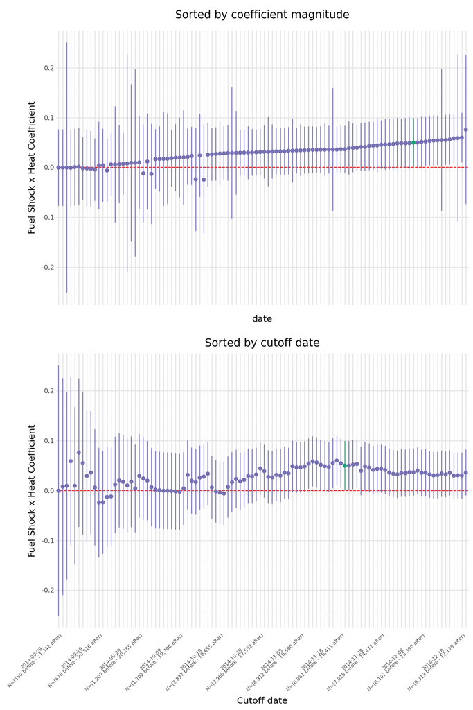

# Glossary

## Outcomes

**CES-D z-score (`cesd_z`)**: standardized depressive-symptom score from the IFLS CES-D items. The raw CES-D score is standardized within survey wave, so coefficients are in wave-specific standard-deviation units.

**CES-D raw score (`cesd_raw`)**: unstandardized depressive-symptom score. Higher values indicate more depressive symptoms.

## Temperature Measures

All main temperature variables are attached to the respondent’s interview date and geography. Variables ending in `_dev` are centered deviations from the mean of that measure in the analysis file. Thus a one-unit change in a temperature deviation is one degree Celsius for temperature levels, or one day for hot-day counts.

**Daily mean temperature (`tmean_c_dev`)**: mean air temperature on the interview date, in degrees Celsius, minus the analysis-sample mean of daily mean temperature.

**7-day mean temperature (`tmean_7d_dev`)**: rolling 7-day mean of daily mean temperature ending on the interview date, with at least four observed days, minus the analysis-sample mean of that rolling measure.

**Daily minimum temperature (`tmin_c_dev`)**: minimum air temperature on the interview date, in degrees Celsius, minus the analysis-sample mean of daily minimum temperature.

**7-day minimum temperature (`tmin_7d_dev`)**: rolling 7-day mean of daily minimum temperature ending on the interview date, with at least four observed days, minus the analysis-sample mean of that rolling measure.

**Wet-bulb temperature (`wetbulb_c_dev`)**: interview-date daily mean wet-bulb temperature, in degrees Celsius, minus the analysis-sample mean. Wet-bulb temperature is computed from hourly air temperature and dewpoint using relative humidity and the Stull wet-bulb approximation, then averaged to the local day.

**7-day wet-bulb temperature (`wetbulb_7d_dev`)**: rolling 7-day mean of daily wet-bulb temperature ending on the interview date, with at least four observed days, minus the analysis-sample mean of that rolling measure.

**7-day hot days (`hot30_7d_dev`)**: count of days in the rolling 7-day window ending on the interview date for which daily maximum temperature exceeds $30^\circ$C, minus the analysis-sample mean of that count.

## Shock And Group Status

**Palm-farmer household (`palm_farmer_hh_ifls4`)**: baseline IFLS4 household indicator equal to one if any household member worked in agriculture and lived in a province classified as a palm-producing province. This is a region-by-sector proxy for palm exposure, not direct observation that the household produced oil palm.

**Palm shock**: the main preview shock specification uses `palm_farmer_hh_ifls4 x ifls5 x heat`. It compares heat sensitivity for baseline palm-proxy households after the palm-price decline period relative to other households and the earlier wave.

**Coal-worker household (`coal_worker_hh_ifls4`)**: baseline IFLS4 household indicator equal to one if any household member worked in mining and lived in a province classified as a coal-producing province. This is a region-by-sector proxy for coal exposure.

**Coal shock**: the main preview shock specification uses `coal_worker_hh_ifls4 x ifls5 x heat`. It compares heat sensitivity for baseline coal-proxy households in IFLS5 relative to other households and the earlier wave.

**Urban vehicle-owning household (`urban_vehicle_hh_ifls4`)**: baseline IFLS4 household indicator equal to one if the household was urban and reported vehicle ownership. This group is used as the fuel-subsidy-cut exposure group.

**Post-subsidy-cut interview (`post_subsidy`)**: indicator equal to one for interviews on or after November 18, 2014, the fuel-subsidy-cut date used in the pipeline.

**Fuel shock**: the main preview shock specification uses `urban_vehicle_hh_ifls4 x post_subsidy x heat` within IFLS5. It compares heat sensitivity for baseline urban vehicle-owning households interviewed after the subsidy cut relative to comparable IFLS5 interviews before the cut.

**Job loss within 1 year (`job_loss_1_yr`)**: indicator equal to one when the respondent reports a last job loss within 365 days of the interview and is not currently working. The job-loss columns interact this contemporaneous stressor with heat.

## Fixed Effects And Controls

**Community fixed effects**: fixed effects for the respondent’s kecamatan-level location. These absorb time-invariant community differences.

**Kecamatan**: Indonesian subdistrict. In this preview, kecamatan is the community-level geography used for fixed effects and clustered standard errors.

**Kabupaten**: Indonesian district or regency, the administrative unit above kecamatan and below province.

**Month and year fixed effects**: fixed effects for interview month-of-year and calendar year. The headline identifying variation is daily weather variation around interview timing within communities, months, and years.

**Wave fixed effects**: IFLS4/IFLS5 survey-wave fixed effects used in pooled specifications when the sample includes both waves.

**Controls**: age, female, years of education, married, and widowed.